# Final Project

Dai Dong

4/30/2021

**Load libraries**

```r
library(ggplot2)
library(tidyverse)
library(caret)
library(mice)
library(VIM)
library(lattice)
library(ROSE)
library(pROC)
library(ROCR)
library(knitr)
library(kableExtra)
library(gridExtra)
library(gbm)
```

Read the data

```r
data <- read.csv("aug_train.csv") %>%
  # Delete enroll_id and city variable
  select(-c(enrollee_id, city))
summary(data)
```

```
##  city_development_index    gender          relevent_experience
##  Min.   :0.4480         Length:19158       Length:19158
##  1st Qu.:0.7400         Class :character   Class :character
##  Median :0.9030         Mode  :character   Mode  :character
##  Mean   :0.8288
##  3rd Qu.:0.9200
##  Max.   :0.9490
##  enrolled_university education_level    major_discipline    experience
##  Length:19158        Length:19158       Length:19158       Length:19158
##  Class :character    Class :character   Class :character   Class :character
##  Mode  :character    Mode  :character   Mode  :character   Mode  :character
##
##
##
##  company_size       company_type       last_new_job       training_hours
##  Length:19158       Length:19158       Length:19158       Min.   :  1.00
##  Class :character   Class :character   Class :character   1st Qu.: 23.00
##  Mode  :character   Mode  :character   Mode  :character   Median : 47.00
##                                                           Mean   : 65.37
##                                                           3rd Qu.: 88.00
##                                                           Max.   :336.00
##      target
##  Min.   :0.0000
##  1st Qu.:0.0000
##  Median :0.0000
##  Mean   :0.2493
##  3rd Qu.:0.0000
##  Max.   :1.0000
```

```r
str(data)
```

```
## 'data.frame':    19158 obs. of  12 variables:
##  $ city_development_index: num  0.92 0.776 0.624 0.789 0.767 0.764 0.92 0.762 0.92 0.92 ...
##  $ gender                : chr  "Male" "Male" "" "" ...
##  $ relevent_experience   : chr  "Has relevent experience" "No relevent experience" "No relevent experience" "No relevent experience" ...
##  $ enrolled_university   : chr  "no_enrollment" "no_enrollment" "Full time course" "" ...
##  $ education_level       : chr  "Graduate" "Graduate" "Graduate" "Graduate" ...
##  $ major_discipline      : chr  "STEM" "STEM" "STEM" "Business Degree" ...
##  $ experience            : chr  ">20" "15" "5" "<1" ...
##  $ company_size          : chr  "" "50-99" "" "" ...
##  $ company_type          : chr  "" "Pvt Ltd" "" "Pvt Ltd" ...
##  $ last_new_job          : chr  "1" ">4" "never" "never" ...
##  $ training_hours        : int  36 47 83 52 8 24 24 18 46 123 ...
##  $ target                : num  1 0 0 1 0 1 0 1 1 0 ...
```

#### Cleaning data

```r
# Recode variables
data <- data %>%
  # Recode variables as factor type
  mutate(gender = as.factor(gender),
         relevent_experience = as.factor(relevent_experience),
         enrolled_university = as.factor(enrolled_university),
         education_level = as.factor(enrolled_university),
         major_discipline = as.factor(major_discipline),
         experience = as.factor(experience), #
         company_size = as.factor(company_size),
         company_type = as.factor(company_type),
         last_new_job = as.factor(last_new_job),
         target = as.factor(target)) %>%
  # Reorder levels of categorical variables in an appropriate order
  mutate(gender =  factor(gender, levels = c("Male", "Female", "Other")),
         enrolled_university = factor(enrolled_university, levels = c("no_enrollment", "Part time course",
                                                                      "Full time course")),
         education_level = factor(education_level, levels = c("no_enrollment", "Part time course",
                                                              "Full time course")),
         major_discipline = factor(major_discipline, levels = c("Arts", "Business Degree", "Humanities",
                                                                "STEM", "Other", "No Major")),
         company_size = ifelse(as.character(company_size) == "10/49", "10-49", as.character(company_size)),
         company_size = as.factor(company_size),
         company_size = factor(company_size, levels = c("<10", "10-49", "50-99", "100-500", "500-999",
                                                        "1000-4999", "5000-9999", "10000+")),
         experience = factor(experience, levels = c("<1", "1", "2", "3", "4", "5", "6", "7", "8", "9", "10", "11",
                                                    "12", "13", "14", "15", "16", "17", "18", "19", "20", ">20")),
         company_type = factor(company_type, levels = c("Early Stage Startup", "Funded Startup", "Pvt Ltd",
                                                        "Public Sector", "NGO", "Other")),
         last_new_job = factor(last_new_job, levels = c("never", "1", "2", "3", "4", ">4")))

str(data)
```

```
## 'data.frame':    19158 obs. of  12 variables:
##  $ city_development_index: num  0.92 0.776 0.624 0.789 0.767 0.764 0.92 0.762 0.92 0.92 ...
##  $ gender                : Factor w/ 3 levels "Male","Female",..: 1 1 NA NA 1 NA 1 1 1 NA ...
##  $ relevent_experience   : Factor w/ 2 levels "Has relevent experience",..: 1 2 2 2 1 1 1 1 1 1 ...
##  $ enrolled_university   : Factor w/ 3 levels "no_enrollment",..: 1 1 3 NA 1 2 1 1 1 1 ...
##  $ education_level       : Factor w/ 3 levels "no_enrollment",..: 1 1 3 NA 1 2 1 1 1 1 ...
##  $ major_discipline      : Factor w/ 6 levels "Arts","Business Degree",..: 4 4 4 2 4 4 NA 4 4 4 ...
##  $ experience            : Factor w/ 22 levels "<1","1","2","3",..: 22 16 6 1 22 12 6 14 8 18 ...
##  $ company_size          : Factor w/ 8 levels "<10","10-49",..: NA 3 NA NA 3 NA 3 1 3 8 ...
##  $ company_type          : Factor w/ 6 levels "Early Stage Startup",..: NA 3 NA 3 2 NA 2 3 3 3 ...
##  $ last_new_job          : Factor w/ 6 levels "never","1","2",..: 2 6 1 1 5 2 2 6 2 6 ...
##  $ training_hours        : int  36 47 83 52 8 24 24 18 46 123 ...
##  $ target                : Factor w/ 2 levels "0","1": 2 1 1 2 1 2 1 2 2 1 ...
```

#### Collapse levels of experience variable

The experience variable has 22 levels; thus, we decide to collapse this variable.

```r
# experience = <1 ~ <1
# experience = [1-5] ~ <=5
# experience = [6-10] ~ <=10
# experience = [11-15] ~ <=15
# experience = [16-20] ~ <=20
# experience = >20 ~ >20
data <- data %>%
  mutate(experience = as.character(experience),
         experience = case_when(experience %in% c("1", "2", "3", "4", "5") ~ "<=5",
                                experience %in% c("6", "7", "8", "9", "10") ~ "<=10",
                                experience %in% c("11", "12", "13", "14", "15") ~ "<=15",
                                experience %in% c("16", "17", "18", "19", "20") ~ "<=20",
                                experience %in% c("<1", ">20") ~ experience),
         experience = factor(experience, levels = c("<1", "<=5", "<=10", "<=15", "<=20", ">20")))
summary(data$experience)
```

```
##   <1  <=5 <=10 <=15 <=20  >20 NA's
##  522 5863 5011 2829 1582 3286   65
```

#### Missing values

```r
# A function to calculate the number of missing values and the percentage of records for each variable that has missing values.
missing_values <- function(dat) {
  df <- as.data.frame(cbind(lapply(lapply(dat, is.na), sum))) %>%
    rename(numberOfObservations = V1)

  # Change the index into the first column
  df <- cbind(Variables = rownames(df), df)
  rownames(df) <- 1:nrow(df)

  # Calculate percentage of missing values
  df <- df %>%
    mutate(numberOfObservations = as.integer(numberOfObservations),
           missingPerc = round(numberOfObservations/nrow(data)*100, 2)) %>%
    filter(numberOfObservations != 0) %>%
    arrange(desc(numberOfObservations))

  return (df)
}

missing_df <- missing_values(data)
missing_df
```

```
##             Variables numberOfObservations missingPerc
## 1        company_type                 6140       32.05
## 2        company_size                 5938       30.99
## 3              gender                 4508       23.53
## 4    major_discipline                 2813       14.68
## 5        last_new_job                  423        2.21
## 6 enrolled_university                  386        2.01
## 7     education_level                  386        2.01
## 8          experience                   65        0.34
```

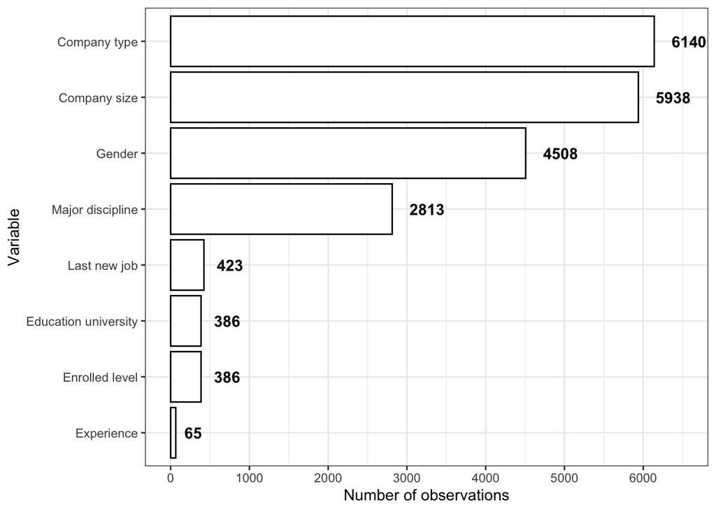

```r
# EDA
missing_df %>%
  arrange(numberOfObservations) %>%
  mutate(Variables = factor(Variables, levels = Variables)) %>%
  ggplot(aes(x=numberOfObservations, y=Variables, label = numberOfObservations)) +
    geom_col(color = "black", fill = "white") +
    geom_text(hjust = -0.5, fontface = "bold") +
    scale_x_continuous(limits = c(0, 6500),
                       breaks = seq(0, 6200, by = 1000)) +
    scale_y_discrete(labels = c("Experience", "Enrolled level", "Education university", "Last new job", "Major discipline", "Gender",
                                "Company size", "Company type")) +
    labs(x = "Number of observations",
         y = "Variable") +
    theme_bw()
```

```r
miss_subset_df <- data[rowSums(is.na(data[,c("enrolled_university", "education_level")])) > 0, ] %>%
  select(c("enrolled_university", "education_level"))
sum(is.na(miss_subset_df)) # 722 => it means that the whole data set contains missing values.
```

```
## [1] 772
```

```r
data <- data %>% filter(complete.cases(enrolled_university))
missing_df <- missing_values(data)
missing_df
```

```
##          Variables numberOfObservations missingPerc
## 1     company_type                 5898       31.42
## 2     company_size                 5701       30.37
## 3           gender                 4335       23.09
## 4 major_discipline                 2656       14.15
## 5     last_new_job                  390        2.08
## 6       experience                   60        0.32
```

For the rest of missing values, we decided to do imputation using MICE package. We assume that the missing data are missing at random (MAR).

```r
# m = no of imputed data set
# maxit = no. of iterations taken to impute missing values
#imputed_data <- mice(data, m=2, maxit = 2, seed = 500)
```

```r
# # Get completed data
# complete_data <- complete(imputed_data)
# sum(is.na(complete_data))
#
# summary(complete_data)
#
# # Save an object to a file
# saveRDS(complete_data, file = "complete_data.rds")
```

```r
# Restore the object
dat <- readRDS(file = "complete_data.rds")
str(dat)
```

```
## 'data.frame':    18772 obs. of  12 variables:
##  $ city_development_index: num  0.92 0.776 0.624 0.767 0.764 0.92 0.762 0.92 0.92 0.624 ...
##  $ gender                : Factor w/ 3 levels "Male","Female",..: 1 1 1 1 2 1 1 1 1 2 ...
##  $ relevent_experience   : Factor w/ 2 levels "Has relevent experience",..: 1 2 2 1 1 1 1 1 1 2 ...
##  $ enrolled_university   : Factor w/ 3 levels "no_enrollment",..: 1 1 3 1 2 1 1 1 1 3 ...
##  $ education_level       : Factor w/ 3 levels "no_enrollment",..: 1 1 3 1 2 1 1 1 1 3 ...
##  $ major_discipline      : Factor w/ 6 levels "Arts","Business Degree",..: 4 4 4 4 4 4 4 4 4 4 ...
##  $ experience            : Factor w/ 6 levels "<1","<=5","<=10",..: 6 4 2 6 4 2 4 3 5 2 ...
##  $ company_size          : Factor w/ 8 levels "<10","10-49",..: 5 3 1 3 1 3 1 3 8 8 ...
##  $ company_type          : Factor w/ 6 levels "Early Stage Startup",..: 3 3 3 2 3 2 3 3 3 3 ...
##  $ last_new_job          : Factor w/ 6 levels "never","1","2",..: 2 6 1 5 2 2 6 2 6 1 ...
##  $ training_hours        : int  36 47 83 8 24 24 18 46 123 32 ...
##  $ target                : Factor w/ 2 levels "0","1": 2 1 1 1 2 1 2 2 1 2 ...
```

```r
summary(dat)
```

```
##  city_development_index    gender                   relevent_experience
##  Min.   :0.448          Male  :16947   Has relevent experience:13597
##  1st Qu.:0.743          Female: 1592   No relevent experience : 5175
##  Median :0.910          Other :  233
##  Mean   :0.830
##  3rd Qu.:0.920
##  Max.   :0.949
##
##        enrolled_university         education_level         major_discipline
##  no_enrollment   :13817    no_enrollment   :13817   Arts           :  300
##  Part time course: 1198    Part time course: 1198   Business Degree:  390
##  Full time course: 3757    Full time course: 3757   Humanities     :  780
##                                                     STEM           :16576
##                                                     Other          :  449
##                                                     No Major       :  277
##
##  experience     company_size               company_type   last_new_job
##  <1  : 500   50-99    :4189   Early Stage Startup:  859   never:2397
##  <=5 :5704   100-500  :3536   Funded Startup     : 1326   1    :8106
##  <=10:4924   10000+   :3022   Pvt Ltd            :13941   2    :2919
##  <=15:2805   10-49    :2026   Public Sector      : 1637   3    :1027
##  <=20:1576   <10      :1948   NGO                :  814   4    :1030
##  >20 :3263   1000-4999:1936   Other              :  195   >4   :3293
##              (Other)  :2115
##  training_hours   target
##  Min.   :  1.00   0:14118
##  1st Qu.: 23.00   1: 4654
##  Median : 47.00
##  Mean   : 65.34
##  3rd Qu.: 88.00
##  Max.   :336.00
##
```

Plot the frequency of gender variable before and after imputation.

```r
# Create a data frame.
gender_df <- data.frame(id = seq(1, nrow(dat), by = 1),
                        bf_impute = data$gender,
                        af_impute = dat$gender)
summary(gender_df)
```

```
##        id         bf_impute      af_impute
##  Min.   :    1   Male  :13041   Male  :16947
##  1st Qu.: 4694   Female: 1218   Female: 1592
##  Median : 9386   Other :  178   Other :  233
##  Mean   : 9386   NA's  : 4335
##  3rd Qu.:14079
##  Max.   :18772
```

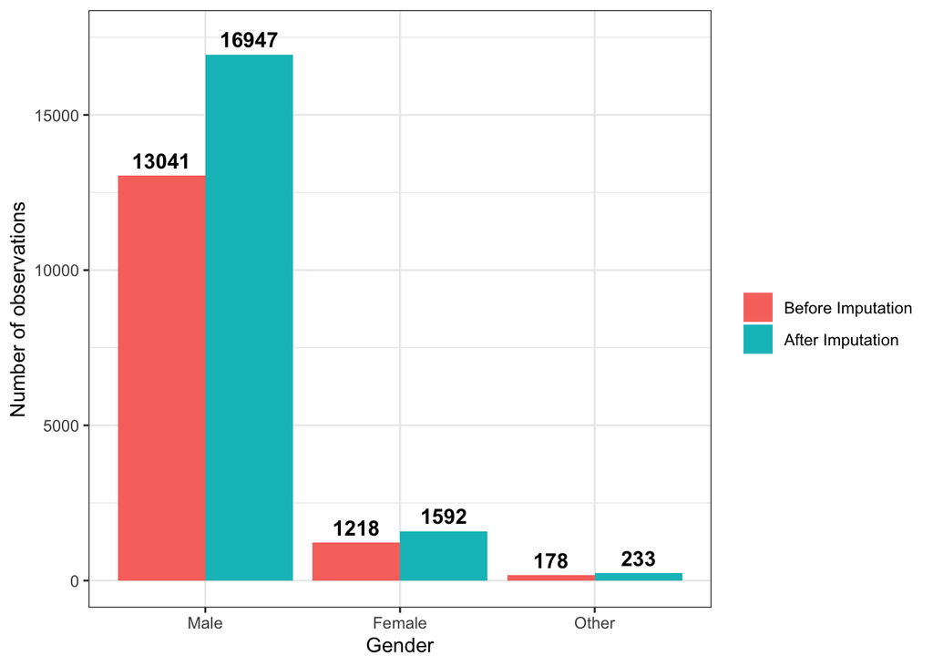

```r
# Change from wide to long format
gender_df <- gender_df %>%
  pivot_longer(cols = -id, names_to = "Imputation", values_to = "Gender")
gender_df <- as.data.frame(table(gender_df$Imputation, gender_df$Gender))
gender_df <- gender_df %>%
  rename(Imputation = Var1,
         Gender = Var2) %>%
  mutate(Imputation = factor(Imputation, levels = c("bf_impute", "af_impute")))

# Plot
ggplot(data=gender_df, aes(x = Gender, y=Freq, fill = Imputation)) +
  geom_bar(stat = "identity", position = position_dodge()) +
  geom_text(aes(label = Freq), fontface = "bold", vjust = -0.5,
             position = position_dodge(.9), size = 4) +
  labs(y = "Number of observations") +
  scale_y_continuous(limits = c(0, 17500)) +
  scale_fill_discrete(name = "",
                      labels = c("Before Imputation", "After Imputation")) +
  theme_bw()
```

```r
# Percentage changes
# Male
(16947-13041)/13041
```

```
## [1] 0.2995169
```

```r
# Female
(1592-1218)/1218
```

```
## [1] 0.3070608
```

```r
# Other
(273/178)/178
```

```
## [1] 0.008616336
```

#### Imbalanced data set

```r
dat <- dat %>%
  mutate(target = ifelse(target == "0", "No", "Yes"),
         target = as.factor(target))

#Frequency of the target variable
table(dat$target)
```

```
##
##    No   Yes
## 14118  4654
```

```r
# Proportion of 2 classes
prop.table(table(dat$target))
```

```
##
##        No       Yes
## 0.7520776 0.2479224
```

## METHOD 1: SYNTHETIC DATA GENERATION

We can see that we have an imbalanced data set with about 25% of positive cases and 75% of negative cases. Even though The imbalance problem is not so severe, we still need to take care of this because it can incur poor predictive performance for the minority class which is the class we are interested in.

To deal with this problem, we will create a sample of synthetic data.

**The data generated from oversampling have expected amount of repeated observations. Data generated from undersampling is deprived of important information from the original data. This leads to inaccuracies in the resulting performance.**

```r
# Split data into training and test set.
set.seed(1999)
train_index <- sort(sample(1:nrow(dat),nrow(dat)*(4/5)))

train_data <- dat[train_index, ]
test_data <- dat[-train_index, ]
```

```r
## Frequency of the target variable in the training data set
table(train_data$target)
```

```
##
##    No   Yes
## 11276  3741
```

```r
# Proportion of 2 classes in the training data set
prop.table(table(train_data$target))
```

```
##
##        No       Yes
## 0.7508823 0.2491177
```

We use `ROSE()` function from ROSE package to generate a newly synthetic training data set with the same number of observations as the original training data set.

```r
#train_balanced_both <- ovun.sample(target ~ ., data = train_data, method = "both", p=0.5, N=nrow(train_data), seed = 1)$data
train_data_balanced <- ROSE(target ~ ., data = train_data, seed = 1999)$data
prop.table(table(train_data_balanced$target))
```

```
##
##        No       Yes
## 0.4975028 0.5024972
```

As you can see now, we have a more balanced data set.

#### Models

**Stepwise with Linear Terms**  
We will use the stepwise regresion model to select variables contribute the most to the model.

```r
# full <- glm(target ~ ., data=train_data_balanced, family="binomial")
# null <- glm(target ~ 1, data=train_data_balanced, family="binomial")
#
# lr_step_mod <- step(null, list(lower=formula(null), upper=formula(full)), data=train_data_balanced, direction="both", trace=0)
# options(scipen = 999)
# summary(lr_step_mod)
#
# # Save an object to a file
# saveRDS(lr_step_mod, file = "lr_step_mod.rds")

# Read the model in
lr_step_mod <- readRDS(file = "lr_step_mod.rds")
lr_step_mod
```

```
##
## Call:  glm(formula = target ~ city_development_index + relevent_experience +
##     company_type + company_size + enrolled_university + last_new_job +
##     experience + gender + training_hours, family = "binomial",
##     data = train_data_balanced)
##
## Coefficients:
##                               (Intercept)
##                                 3.6259746
##                    city_development_index
##                                -5.4896624
## relevent_experienceNo relevent experience
##                                 0.5102250
##                company_typeFunded Startup
##                                 0.0338461
##                       company_typePvt Ltd
##                                 0.2065112
##                 company_typePublic Sector
##                                 0.8011241
##                           company_typeNGO
##                                 0.4565626
##                         company_typeOther
##                                 1.0032004
##                         company_size10-49
##                                 0.5481697
##                         company_size50-99
##                                 0.3343678
##                       company_size100-500
##                                 0.1735268
##                       company_size500-999
##                                 0.2427108
##                     company_size1000-4999
##                                 0.3596630
##                     company_size5000-9999
##                                 0.3904914
##                        company_size10000+
##                                 0.5334567
##       enrolled_universityPart time course
##                                 0.1415280
##       enrolled_universityFull time course
```

[output cut: 16 more lines]

```
##                                -0.4735546
##                            experience<=20
##                                -0.6030120
##                             experience>20
##                                -0.4010963
##                              genderFemale
##                                 0.1837224
##                               genderOther
##                                -0.2453877
##                            training_hours
##                                -0.0006249
##
## Degrees of Freedom: 15016 Total (i.e. Null);  14987 Residual
## Null Deviance:       20820
## Residual Deviance: 18240     AIC: 18300
```

**Logistic Regression Model**

```r
# set.seed(1999)
# lr_mod <- train(formula(lr_step_mod),
#                  data = train_data_balanced,
#                  method = "glm",
#                  family = "binomial",
#                  metric="ROC",
#                  trControl = trainControl(method="cv", number = 5,
#                                           summaryFunction = twoClassSummary,
#                                           classProbs = TRUE,
#                                           savePredictions = TRUE),
#                  preProcess = c("center", "scale"))
# lr_mod
#
# # Save an object to a file
# saveRDS(lr_mod, file = "lr_mod.rds")
```

```r
# Read the model back
lr_mod <- readRDS(file = "lr_mod.rds")
lr_mod
```

```
## Generalized Linear Model
##
## 15017 samples
##     9 predictor
##     2 classes: 'No', 'Yes'
##
## Pre-processing: centered (29), scaled (29)
## Resampling: Cross-Validated (5 fold)
## Summary of sample sizes: 12012, 12014, 12014, 12014, 12014
## Resampling results:
##
##   ROC        Sens       Spec
##   0.7277003  0.7139611  0.6527988
```

```r
# TRAINING DATA SET
# Predict on training set
lr_mod_est_train <- predict(lr_mod, train_data_balanced)
# Confusion matrix
confusionMatrix(train_data_balanced$target, lr_mod_est_train, positive="Yes")
```

```
## Confusion Matrix and Statistics
##
##           Reference
## Prediction   No  Yes
##        No  5348 2123
##        Yes 2605 4941
##
##                Accuracy : 0.6852
##                  95% CI : (0.6777, 0.6926)
##     No Information Rate : 0.5296
##     P-Value [Acc > NIR] : < 2.2e-16
##
##                   Kappa : 0.3705
##
##  Mcnemar's Test P-Value : 2.647e-12
##
##             Sensitivity : 0.6995
##             Specificity : 0.6725
##          Pos Pred Value : 0.6548
##          Neg Pred Value : 0.7158
##              Prevalence : 0.4704
##          Detection Rate : 0.3290
##    Detection Prevalence : 0.5025
##       Balanced Accuracy : 0.6860
##
##        'Positive' Class : Yes
##
```

```r
# TEST DATA SET
# Predicted value on test set
lr_mod_est_test <- predict(lr_mod, newdata = test_data)

# Confusion matrix
confusionMatrix(lr_mod_est_test, test_data$target, positive = "Yes")
```

```
## Confusion Matrix and Statistics
##
##           Reference
## Prediction   No  Yes
##        No  2038  306
##        Yes  804  607
##
##                Accuracy : 0.7044
##                  95% CI : (0.6895, 0.719)
##     No Information Rate : 0.7569
##     P-Value [Acc > NIR] : 1
##
##                   Kappa : 0.3223
##
##  Mcnemar's Test P-Value : <2e-16
##
##             Sensitivity : 0.6648
##             Specificity : 0.7171
##          Pos Pred Value : 0.4302
##          Neg Pred Value : 0.8695
##              Prevalence : 0.2431
##          Detection Rate : 0.1617
##    Detection Prevalence : 0.3758
##       Balanced Accuracy : 0.6910
##
##        'Positive' Class : Yes
##
```

```r
# AUC
lr_mod_est_prob <-  predict(lr_mod, newdata = test_data, type="prob")
lr_test_auc <- roc(test_data$target, lr_mod_est_prob$Yes)$auc
lr_test_auc
```

```
## Area under the curve: 0.7378
```

**KNN Model**

```r
# set.seed(1999)
# knn_mod <- train(formula(lr_step_mod),
#                  data = train_data_balanced,
#                  method = "knn",
#                  metric="ROC",
#                  trControl = trainControl(method="cv", number = 5,
#                                           summaryFunction = twoClassSummary,
#                                           classProbs = TRUE,
#                                           savePredictions = TRUE),
#                  preProcess = c("center", "scale"),
#                  tuneGrid=data.frame(k=1:10))
# knn_mod
#
# # Save an object to a file
# saveRDS(knn_mod, file = "knn_mod.rds")
```

```r
# Read the model back
knn_mod <- readRDS(file = "knn_mod.rds")
knn_mod
```

```
## k-Nearest Neighbors
##
## 15017 samples
##     9 predictor
##     2 classes: 'No', 'Yes'
##
## Pre-processing: centered (29), scaled (29)
## Resampling: Cross-Validated (5 fold)
## Summary of sample sizes: 12012, 12014, 12014, 12014, 12014
## Resampling results across tuning parameters:
##
##   k   ROC        Sens       Spec
##    1  0.7480716  0.7316303  0.7645130
##    2  0.7763160  0.6934833  0.7332377
##    3  0.7792554  0.7045928  0.7369494
##    4  0.7735270  0.6863885  0.7197221
##    5  0.7685397  0.6930806  0.7193247
##    6  0.7650332  0.6865221  0.7068673
##    7  0.7593773  0.6908045  0.7069994
##    8  0.7562703  0.6841117  0.6975895
##    9  0.7529149  0.6897333  0.6913616
##   10  0.7504678  0.6885275  0.6802293
##
## ROC was used to select the optimal model using the largest value.
## The final value used for the model was k = 3.
```

```r
# TRAINING DATA SET
# Predict on training set
knn_mod_est_train <- predict(knn_mod, train_data_balanced)
# Confusion matrix
confusionMatrix(train_data_balanced$target, knn_mod_est_train, positive="Yes")
```

```
## Confusion Matrix and Statistics
##
##           Reference
## Prediction   No  Yes
##        No  6408 1063
##        Yes  848 6698
##
##                Accuracy : 0.8727
##                  95% CI : (0.8673, 0.878)
##     No Information Rate : 0.5168
##     P-Value [Acc > NIR] : < 2.2e-16
##
##                   Kappa : 0.7454
##
##  Mcnemar's Test P-Value : 9.813e-07
##
##             Sensitivity : 0.8630
##             Specificity : 0.8831
##          Pos Pred Value : 0.8876
##          Neg Pred Value : 0.8577
##              Prevalence : 0.5168
##          Detection Rate : 0.4460
##    Detection Prevalence : 0.5025
##       Balanced Accuracy : 0.8731
##
##        'Positive' Class : Yes
##
```

```r
# TEST DATA SET
# Predicted value on test set
knn_mod_est_test <- predict(knn_mod, newdata = test_data)

# Confusion matrix
confusionMatrix(knn_mod_est_test, test_data$target, positive = "Yes")
```

```
## Confusion Matrix and Statistics
##
##           Reference
## Prediction   No  Yes
##        No  1869  432
##        Yes  973  481
##
##                Accuracy : 0.6258
##                  95% CI : (0.6101, 0.6413)
##     No Information Rate : 0.7569
##     P-Value [Acc > NIR] : 1
##
##                   Kappa : 0.1536
##
##  Mcnemar's Test P-Value : <2e-16
##
##             Sensitivity : 0.5268
##             Specificity : 0.6576
##          Pos Pred Value : 0.3308
##          Neg Pred Value : 0.8123
##              Prevalence : 0.2431
##          Detection Rate : 0.1281
##    Detection Prevalence : 0.3872
##       Balanced Accuracy : 0.5922
##
##        'Positive' Class : Yes
##
```

```r
# AUC
knn_mod_est_prob <-  predict(knn_mod, newdata = test_data, type="prob")
knn_test_auc <- roc(test_data$target, knn_mod_est_prob$Yes)$auc
knn_test_auc
```

```
## Area under the curve: 0.6069
```

**Random Forest Model**

```r
# set.seed(1999)
# rf_mod <- train(formula(lr_step_mod),
#                 data = train_data_balanced,
#                 method = "rf",
#                 metric="ROC",
#                 trControl = trainControl(method="cv", number = 5,
#                                           summaryFunction = twoClassSummary,
#                                           classProbs = TRUE,
#                                           savePredictions = TRUE),
#                 tuneGrid=data.frame(mtry=1:9),
#                 ntree=100)
# rf_mod
#
# # Save an object to a file
# saveRDS(rf_mod, file = "rf_mod.rds")
```

```r
# Read RDS file
rf_mod <- readRDS(file = "rf_mod.rds")
rf_mod
```

```
## Random Forest
##
## 15017 samples
##     9 predictor
##     2 classes: 'No', 'Yes'
##
## No pre-processing
## Resampling: Cross-Validated (5 fold)
## Summary of sample sizes: 12012, 12014, 12014, 12014, 12014
## Resampling results across tuning parameters:
##
##   mtry  ROC        Sens       Spec
##   1     0.6910626  0.7448784  0.5397590
##   2     0.7413392  0.7460860  0.6492202
##   3     0.7727897  0.7618803  0.6778466
##   4     0.7930806  0.7685729  0.7024958
##   5     0.8046613  0.7614760  0.7267478
##   6     0.8125838  0.7549188  0.7414576
##   7     0.8135792  0.7517051  0.7434456
##   8     0.8131736  0.7476904  0.7463611
##   9     0.8085301  0.7434072  0.7441075
##
## ROC was used to select the optimal model using the largest value.
## The final value used for the model was mtry = 7.
```

```r
varImp(rf_mod, scale=FALSE)
```

```
## rf variable importance
##
##   only 20 most important variables shown (out of 29)
##
##                                           Overall
## city_development_index                    2120.89
## training_hours                            1202.52
## relevent_experienceNo relevent experience  174.41
## enrolled_universityFull time course        151.27
## last_new_job1                              144.79
## company_size50-99                          121.39
## company_size100-500                        119.29
## experience<=5                              108.20
## genderFemale                               107.73
## last_new_job2                              105.44
## company_typePvt Ltd                        102.61
## company_size10000+                          97.13
## experience<=10                              94.62
## company_size1000-4999                       91.03
## last_new_job>4                              86.93
## company_typePublic Sector                   86.47
## company_size10-49                           82.18
## experience>20                               81.05
## experience<=15                              78.48
## enrolled_universityPart time course         77.62
```

```r
# TRAINING DATA SET
# Predict on training set
rf_mod_est_train <- predict(rf_mod, train_data_balanced)

# Confusion matrix
confusionMatrix(train_data_balanced$target, rf_mod_est_train, positive="Yes")
```

```
## Confusion Matrix and Statistics
##
##           Reference
## Prediction   No  Yes
##        No  7087  384
##        Yes  606 6940
##
##                Accuracy : 0.9341
##                  95% CI : (0.93, 0.938)
##     No Information Rate : 0.5123
##     P-Value [Acc > NIR] : < 2.2e-16
##
##                   Kappa : 0.8682
##
##  Mcnemar's Test P-Value : 2.159e-12
##
##             Sensitivity : 0.9476
##             Specificity : 0.9212
##          Pos Pred Value : 0.9197
##          Neg Pred Value : 0.9486
##              Prevalence : 0.4877
##          Detection Rate : 0.4621
##    Detection Prevalence : 0.5025
##       Balanced Accuracy : 0.9344
##
##        'Positive' Class : Yes
##
```

```r
# TEST DATA SET
# Predicted value on test set
rf_mod_est_test <- predict(rf_mod, newdata = test_data)

# Confusion matrix
confusionMatrix(rf_mod_est_test, test_data$target, positive = "Yes")
```

```
## Confusion Matrix and Statistics
##
##           Reference
## Prediction   No  Yes
##        No  2173  369
##        Yes  669  544
##
##                Accuracy : 0.7236
##                  95% CI : (0.709, 0.7378)
##     No Information Rate : 0.7569
##     P-Value [Acc > NIR] : 1
##
##                   Kappa : 0.3243
##
##  Mcnemar's Test P-Value : <2e-16
##
##             Sensitivity : 0.5958
##             Specificity : 0.7646
##          Pos Pred Value : 0.4485
##          Neg Pred Value : 0.8548
##              Prevalence : 0.2431
##          Detection Rate : 0.1449
##    Detection Prevalence : 0.3230
##       Balanced Accuracy : 0.6802
##
##        'Positive' Class : Yes
##
```

```r
# AUC
rf_mod_est_prob <-  predict(rf_mod, newdata = test_data, type="prob")
rf_test_auc <- roc(test_data$target, rf_mod_est_prob$Yes)$auc
rf_test_auc
```

```
## Area under the curve: 0.7168
```

**Boosting Model**

```r
# set.seed(1999)
# boost_mod <- train(formula(lr_step_mod),
#                  data = train_data_balanced,
#                  method = "gbm",
#                  metric="ROC",
#                  trControl = trainControl(method="cv", number = 5,
#                                           summaryFunction = twoClassSummary,
#                                           classProbs = TRUE,
#                                           savePredictions = TRUE),
#                  tuneGrid = expand.grid(n.trees=seq(100, 200, by=50),
#                                         interaction.depth=1:7,
#                                         shrinkage=0.1,
#                                         n.minobsinnode=10),
#                  verbose = F)
#
# boost_mod
#
# # Save an object to a file
# saveRDS(boost_mod, file = "boost_mod.rds")
```

```r
# Read the model back
boost_mod <- readRDS(file = "boost_mod.rds")
boost_mod
```

```
## Stochastic Gradient Boosting
##
## 15017 samples
##     9 predictor
##     2 classes: 'No', 'Yes'
##
## No pre-processing
## Resampling: Cross-Validated (5 fold)
## Summary of sample sizes: 12012, 12014, 12014, 12014, 12014
## Resampling results across tuning parameters:
##
##   interaction.depth  n.trees  ROC        Sens       Spec
##   1                  100      0.7403668  0.7600070  0.6208597
##   1                  150      0.7430516  0.7555888  0.6305350
##   1                  200      0.7436806  0.7509044  0.6383533
##   2                  100      0.7471813  0.7393932  0.6550513
##   2                  150      0.7488619  0.7348431  0.6561118
##   2                  200      0.7500191  0.7333712  0.6611469
##   3                  100      0.7506247  0.7355134  0.6624711
##   3                  150      0.7524998  0.7345763  0.6667118
##   3                  200      0.7540449  0.7344423  0.6685680
##   4                  100      0.7510886  0.7339073  0.6614110
##   4                  150      0.7533067  0.7308273  0.6649905
##   4                  200      0.7549013  0.7302918  0.6660502
##   5                  100      0.7534920  0.7343080  0.6664485
##   5                  150      0.7561113  0.7321661  0.6697617
##   5                  200      0.7574476  0.7297567  0.6734724
##   6                  100      0.7542072  0.7348428  0.6664476
##   6                  150      0.7563758  0.7294886  0.6690987
##   6                  200      0.7578336  0.7282831  0.6717503
##   7                  100      0.7578585  0.7347087  0.6693636
##   7                  150      0.7597334  0.7340397  0.6746653
##   7                  200      0.7604233  0.7292208  0.6769184
##
## Tuning parameter 'shrinkage' was held constant at a value of 0.1
##
## Tuning parameter 'n.minobsinnode' was held constant at a value of 10
## ROC was used to select the optimal model using the largest value.
## The final values used for the model were n.trees = 200, interaction.depth =
##  7, shrinkage = 0.1 and n.minobsinnode = 10.
```

```r
# TRAINING DATA SET
# Predict on training set
boost_mod_est_train <- predict(boost_mod, train_data_balanced)

# Confusion matrix
confusionMatrix(train_data_balanced$target, boost_mod_est_train, positive="Yes")
```

```
## Confusion Matrix and Statistics
##
##           Reference
## Prediction   No  Yes
##        No  5706 1765
##        Yes 2259 5287
##
##                Accuracy : 0.732
##                  95% CI : (0.7249, 0.7391)
##     No Information Rate : 0.5304
##     P-Value [Acc > NIR] : < 2.2e-16
##
##                   Kappa : 0.4642
##
##  Mcnemar's Test P-Value : 7.742e-15
##
##             Sensitivity : 0.7497
##             Specificity : 0.7164
##          Pos Pred Value : 0.7006
##          Neg Pred Value : 0.7638
##              Prevalence : 0.4696
##          Detection Rate : 0.3521
##    Detection Prevalence : 0.5025
##       Balanced Accuracy : 0.7331
##
##        'Positive' Class : Yes
##
```

```r
# TEST DATA SET
# Predicted value on test set
boost_mod_est_test <- predict(boost_mod, newdata = test_data)

# Confusion matrix
confusionMatrix(boost_mod_est_test, test_data$target, positive = "Yes")
```

```
## Confusion Matrix and Statistics
##
##           Reference
## Prediction   No  Yes
##        No  2208  362
##        Yes  634  551
##
##                Accuracy : 0.7348
##                  95% CI : (0.7203, 0.7488)
##     No Information Rate : 0.7569
##     P-Value [Acc > NIR] : 0.9992
##
##                   Kappa : 0.3455
##
##  Mcnemar's Test P-Value : <2e-16
##
##             Sensitivity : 0.6035
##             Specificity : 0.7769
##          Pos Pred Value : 0.4650
##          Neg Pred Value : 0.8591
##              Prevalence : 0.2431
##          Detection Rate : 0.1467
##    Detection Prevalence : 0.3156
##       Balanced Accuracy : 0.6902
##
##        'Positive' Class : Yes
##
```

```r
# AUC
boost_mod_est_prob <-  predict(boost_mod, newdata = test_data, type="prob")
boost_test_auc <- roc(test_data$target, boost_mod_est_prob$Yes)$auc
boost_test_auc
```

```
## Area under the curve: 0.7321
```

```r
varImp(boost_mod, scale=FALSE)
```

```
## gbm variable importance
##
##   only 20 most important variables shown (out of 29)
##
##                                           Overall
## city_development_index                    1989.38
## training_hours                             563.97
## relevent_experienceNo relevent experience  260.81
## company_typePublic Sector                  113.18
## enrolled_universityFull time course        108.00
## last_new_job1                               76.30
## experience>20                               56.97
## company_size10000+                          45.76
## company_size10-49                           38.40
## enrolled_universityPart time course         36.10
## genderFemale                                35.02
## experience<=20                              33.16
## last_new_job4                               31.06
## experience<=15                              29.99
## last_new_job>4                              27.85
## company_size100-500                         27.67
## last_new_job3                               27.55
## company_typePvt Ltd                         27.46
## last_new_job2                               25.90
## company_size50-99                           25.36
```

**LDA Model**

```r
# set.seed(1999)
# lda_mod <- train(formula(lr_step_mod),
#                  data = train_data_balanced,
#                  method = "lda",
#                  metric="ROC",
#                  trControl = trainControl(method="cv", number = 5,
#                                           summaryFunction = twoClassSummary,
#                                           classProbs = TRUE,
#                                           savePredictions = TRUE),
#                  preProcess = c("center", "scale"))
#
# lda_mod
#
# # Save an object to a file
# saveRDS(lda_mod, file = "lda_mod.rds")
```

```r
# Read the model back
lda_mod <- readRDS(file = "lda_mod.rds")
lda_mod
```

```
## Linear Discriminant Analysis
##
## 15017 samples
##     9 predictor
##     2 classes: 'No', 'Yes'
##
## Pre-processing: centered (29), scaled (29)
## Resampling: Cross-Validated (5 fold)
## Summary of sample sizes: 12012, 12014, 12014, 12014, 12014
## Resampling results:
##
##   ROC        Sens       Spec
##   0.7274004  0.7214569  0.6453781
```

```r
# TRAINING DATA SET
# Predict on training set
lda_mod_est_train <- predict(lda_mod, train_data_balanced)

# Confusion matrix
confusionMatrix(train_data_balanced$target, lda_mod_est_train, positive="Yes")
```

```
## Confusion Matrix and Statistics
##
##           Reference
## Prediction   No  Yes
##        No  5403 2068
##        Yes 2662 4884
##
##                Accuracy : 0.685
##                  95% CI : (0.6775, 0.6924)
##     No Information Rate : 0.5371
##     P-Value [Acc > NIR] : < 2.2e-16
##
##                   Kappa : 0.3703
##
##  Mcnemar's Test P-Value : < 2.2e-16
##
##             Sensitivity : 0.7025
##             Specificity : 0.6699
##          Pos Pred Value : 0.6472
##          Neg Pred Value : 0.7232
##              Prevalence : 0.4629
##          Detection Rate : 0.3252
##    Detection Prevalence : 0.5025
##       Balanced Accuracy : 0.6862
##
##        'Positive' Class : Yes
##
```

```r
# TEST DATA SET
# Predicted value on test set
lda_mod_est_test <- predict(lda_mod, newdata = test_data)

# Confusion matrix
confusionMatrix(lda_mod_est_test, test_data$target, positive = "Yes")
```

```
## Confusion Matrix and Statistics
##
##           Reference
## Prediction   No  Yes
##        No  2066  312
##        Yes  776  601
##
##                Accuracy : 0.7103
##                  95% CI : (0.6955, 0.7247)
##     No Information Rate : 0.7569
##     P-Value [Acc > NIR] : 1
##
##                   Kappa : 0.3286
##
##  Mcnemar's Test P-Value : <2e-16
##
##             Sensitivity : 0.6583
##             Specificity : 0.7270
##          Pos Pred Value : 0.4365
##          Neg Pred Value : 0.8688
##              Prevalence : 0.2431
##          Detection Rate : 0.1601
##    Detection Prevalence : 0.3667
##       Balanced Accuracy : 0.6926
##
##        'Positive' Class : Yes
##
```

```r
# AUC
lda_mod_est_prob <-  predict(lda_mod, newdata = test_data, type="prob")
lda_test_auc <- roc(test_data$target, lda_mod_est_prob$Yes)$auc
lda_test_auc
```

```
## Area under the curve: 0.738
```

**QDA Model**

```r
# set.seed(1999)
# qda_mod <- train(formula(lr_step_mod),
#                  data = train_data_balanced,
#                  method = "qda",
#                  metric="ROC",
#                  trControl = trainControl(method="cv", number = 5,
#                                           summaryFunction = twoClassSummary,
#                                           classProbs = TRUE,
#                                           savePredictions = TRUE),
#                  preProcess = c("center", "scale"))
#
# qda_mod
#
# # Save an object to a file
# saveRDS(qda_mod, file = "qda_mod.rds")
```

```r
# Read the model back
qda_mod <- readRDS(file = "qda_mod.rds")
qda_mod
```

```
## Quadratic Discriminant Analysis
##
## 15017 samples
##     9 predictor
##     2 classes: 'No', 'Yes'
##
## Pre-processing: centered (29), scaled (29)
## Resampling: Cross-Validated (5 fold)
## Summary of sample sizes: 12012, 12014, 12014, 12014, 12014
## Resampling results:
##
##   ROC        Sens      Spec
##   0.6985698  0.706867  0.606946
```

```r
# TRAINING DATA SET
# Predict on training set
qda_mod_est_train <- predict(qda_mod, train_data_balanced)

# Confusion matrix
confusionMatrix(train_data_balanced$target, qda_mod_est_train, positive="Yes")
```

```
## Confusion Matrix and Statistics
##
##           Reference
## Prediction   No  Yes
##        No  5337 2134
##        Yes 2914 4632
##
##                Accuracy : 0.6638
##                  95% CI : (0.6562, 0.6714)
##     No Information Rate : 0.5494
##     P-Value [Acc > NIR] : < 2.2e-16
##
##                   Kappa : 0.328
##
##  Mcnemar's Test P-Value : < 2.2e-16
##
##             Sensitivity : 0.6846
##             Specificity : 0.6468
##          Pos Pred Value : 0.6138
##          Neg Pred Value : 0.7144
##              Prevalence : 0.4506
##          Detection Rate : 0.3085
##    Detection Prevalence : 0.5025
##       Balanced Accuracy : 0.6657
##
##        'Positive' Class : Yes
##
```

```r
# TEST DATA SET
# Predicted value on test set
qda_mod_est_test <- predict(qda_mod, newdata = test_data)

# Confusion matrix
confusionMatrix(qda_mod_est_test, test_data$target, positive = "Yes")
```

```
## Confusion Matrix and Statistics
##
##           Reference
## Prediction   No  Yes
##        No  2014  339
##        Yes  828  574
##
##                Accuracy : 0.6892
##                  95% CI : (0.6741, 0.704)
##     No Information Rate : 0.7569
##     P-Value [Acc > NIR] : 1
##
##                   Kappa : 0.2855
##
##  Mcnemar's Test P-Value : <2e-16
##
##             Sensitivity : 0.6287
##             Specificity : 0.7087
##          Pos Pred Value : 0.4094
##          Neg Pred Value : 0.8559
##              Prevalence : 0.2431
##          Detection Rate : 0.1529
##    Detection Prevalence : 0.3734
##       Balanced Accuracy : 0.6687
##
##        'Positive' Class : Yes
##
```

```r
# AUC
qda_mod_est_prob <-  predict(qda_mod, newdata = test_data, type="prob")
qda_test_auc <- roc(test_data$target, qda_mod_est_prob$Yes)$auc
qda_test_auc
```

```
## Area under the curve: 0.6986
```

#### Evaluation

```r
results<-data.frame(
  Model = c("Logistic Regression", "KNN", "Random Forest", "Boosting", "LDA", "QDA"),
  ROC.Valid = c(lr_test_auc, knn_test_auc, rf_test_auc, boost_test_auc, lda_test_auc, qda_test_auc),
  Sens.Valid = c(sensitivity(lr_mod_est_test, test_data$target, positive="Yes"),
                 sensitivity(knn_mod_est_test, test_data$target, positive="Yes"),
                 sensitivity(rf_mod_est_test, test_data$target, positive="Yes"),
                 sensitivity(boost_mod_est_test, test_data$target, positive="Yes"),
                 sensitivity(lda_mod_est_test, test_data$target, positive="Yes"),
                 sensitivity(qda_mod_est_test, test_data$target, positive="Yes")),
  Spec.Valid = c(sensitivity(lr_mod_est_test, test_data$target),
                 sensitivity(knn_mod_est_test, test_data$target),
                 sensitivity(rf_mod_est_test, test_data$target),
                 sensitivity(boost_mod_est_test, test_data$target),
                 sensitivity(lda_mod_est_test, test_data$target),
                 sensitivity(qda_mod_est_test, test_data$target))
)

kable(results) %>%
  kable_styling()
```

| Model | ROC.Valid | Sens.Valid | Spec.Valid |
| --- | --- | --- | --- |
| Logistic Regression | 0.7378021 | 0.6648412 | 0.7171006 |
| KNN | 0.6069035 | 0.5268346 | 0.6576355 |
| Random Forest | 0.7167524 | 0.5958379 | 0.7646024 |
| Boosting | 0.7321156 | 0.6035049 | 0.7769177 |
| LDA | 0.7379636 | 0.6582694 | 0.7269529 |
| QDA | 0.6985539 | 0.6286966 | 0.7086559 |

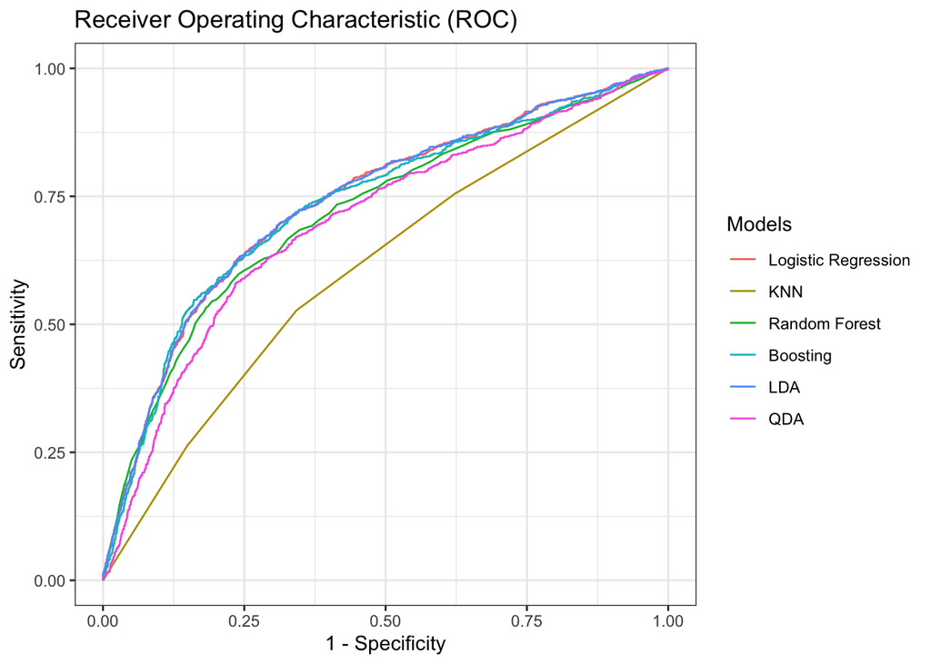

```r
# Plot ROC
roc_df <- list("Logistic Regression" = roc(test_data$target, lr_mod_est_prob$Yes),
               "KNN" = roc(test_data$target, knn_mod_est_prob$Yes),
               "Random Forest" = roc(test_data$target, rf_mod_est_prob$Yes),
               "Boosting" = roc(test_data$target, boost_mod_est_prob$Yes),
               "LDA" = roc(test_data$target, lda_mod_est_prob$Yes),
               "QDA" = roc(test_data$target, qda_mod_est_prob$Yes))

ggroc(roc_df, legacy.axes = TRUE) +
  labs(title = "Receiver Operating Characteristic (ROC)",
       y = "Sensitivity",
       x = "1 - Specificity") +
  scale_color_discrete(name = "Models")+
  theme_bw()
```

#### Chosen model: Logistic Regression Model

```r
lr_mod$finalModel
```

```
##
## Call:  NULL
##
## Coefficients:
##                                 (Intercept)
##                                     0.03478
##                      city_development_index
##                                    -0.75508
## `relevent_experienceNo relevent experience`
##                                     0.23591
##                `company_typeFunded Startup`
##                                     0.00830
##                       `company_typePvt Ltd`
##                                     0.09102
##                 `company_typePublic Sector`
##                                     0.23879
##                             company_typeNGO
##                                     0.09638
##                           company_typeOther
##                                     0.09943
##                         `company_size10-49`
##                                     0.17194
##                         `company_size50-99`
##                                     0.13867
##                       `company_size100-500`
##                                     0.06753
##                       `company_size500-999`
##                                     0.06118
##                     `company_size1000-4999`
##                                     0.10791
##                     `company_size5000-9999`
##                                     0.07917
##                        `company_size10000+`
##                                     0.20154
##       `enrolled_universityPart time course`
##                                     0.03464
##       `enrolled_universityFull time course`
##                                     0.16325
##                               last_new_job1
##                                     0.21643
```

[output cut: 13 more lines]

```
##                                    -0.16189
##                            `experience<=20`
##                                    -0.15914
##                             `experience>20`
##                                    -0.14576
##                                genderFemale
##                                     0.05285
##                                 genderOther
##                                    -0.02685
##                              training_hours
##                                    -0.03750
##
## Degrees of Freedom: 15016 Total (i.e. Null);  14987 Residual
## Null Deviance:       20820
## Residual Deviance: 18240     AIC: 18300
```

```r
exp(lr_mod$finalModel$coefficients)
```

```
##                                 (Intercept)
##                                   1.0353941
##                      city_development_index
##                                   0.4699742
## `relevent_experienceNo relevent experience`
##                                   1.2660601
##                `company_typeFunded Startup`
##                                   1.0083344
##                       `company_typePvt Ltd`
##                                   1.0952931
##                 `company_typePublic Sector`
##                                   1.2697168
##                             company_typeNGO
##                                   1.1011796
##                           company_typeOther
##                                   1.1045465
##                         `company_size10-49`
##                                   1.1876030
##                         `company_size50-99`
##                                   1.1487442
##                       `company_size100-500`
##                                   1.0698629
##                       `company_size500-999`
##                                   1.0630927
##                     `company_size1000-4999`
##                                   1.1139498
##                     `company_size5000-9999`
##                                   1.0823924
##                        `company_size10000+`
##                                   1.2232865
##       `enrolled_universityPart time course`
##                                   1.0352460
##       `enrolled_universityFull time course`
##                                   1.1773357
##                               last_new_job1
##                                   1.2416351
##                               last_new_job2
##                                   1.1634036
##                               last_new_job3
##                                   1.1024989
##                               last_new_job4
##                                   1.1526060
##                            `last_new_job>4`
##                                   1.1663363
##                             `experience<=5`
##                                   0.8815266
##                            `experience<=10`
##                                   0.8379594
##                            `experience<=15`
##                                   0.8505368
##                            `experience<=20`
##                                   0.8528777
##                             `experience>20`
##                                   0.8643687
##                                genderFemale
##                                   1.0542714
##                                 genderOther
##                                   0.9735061
##                              training_hours
##                                   0.9631921
```

```r
## odds ratios and 95% CI
exp(cbind(OR = lr_mod$finalModel$coefficients, confint(lr_mod$finalModel)))
```

```
##                                                    OR     2.5 %    97.5 %
## (Intercept)                                 1.0353941 0.9997190 1.0723722
## city_development_index                      0.4699742 0.4513207 0.4892497
## `relevent_experienceNo relevent experience` 1.2660601 1.2134061 1.3210939
## `company_typeFunded Startup`                1.0083344 0.9547274 1.0648874
## `company_typePvt Ltd`                       1.0952931 1.0109649 1.1867242
## `company_typePublic Sector`                 1.2697168 1.1906509 1.3542074
## company_typeNGO                             1.1011796 1.0464845 1.1588139
## company_typeOther                           1.1045465 1.0623024 1.1491930
## `company_size10-49`                         1.1876030 1.1308850 1.2473462
## `company_size50-99`                         1.1487442 1.0845252 1.2169683
## `company_size100-500`                       1.0698629 1.0115166 1.1317139
## `company_size500-999`                       1.0630927 1.0162585 1.1121410
## `company_size1000-4999`                     1.1139498 1.0608067 1.1698539
## `company_size5000-9999`                     1.0823924 1.0380038 1.1286946
## `company_size10000+`                        1.2232865 1.1573375 1.2932169
## `enrolled_universityPart time course`       1.0352460 0.9994085 1.0723948
## `enrolled_universityFull time course`       1.1773357 1.1305180 1.2261856
## last_new_job1                               1.2416351 1.1707781 1.3168967
## last_new_job2                               1.1634036 1.1054469 1.2244978
## last_new_job3                               1.1024989 1.0573929 1.1495250
## last_new_job4                               1.1526060 1.1051813 1.2020709
## `last_new_job>4`                            1.1663363 1.1042535 1.2320077
## `experience<=5`                             0.8815266 0.7946440 0.9759227
## `experience<=10`                            0.8379594 0.7590805 0.9234026
## `experience<=15`                            0.8505368 0.7844504 0.9210864
## `experience<=20`                            0.8528777 0.7974735 0.9113532
## `experience>20`                             0.8643687 0.7921392 0.9420618
## genderFemale                                1.0542714 1.0176079 1.0923136
## genderOther                                 0.9735061 0.9395306 1.0083048
## training_hours                              0.9631921 0.9298055 0.9977219
```

## METHOD 2: THRESHOLD ADJUSTMENT

#### Models

**Stepwise with Linear Terms**  
We will still use the stepwise regresion model to select variables contribute the most to the model.

```r
# full <- glm(target ~ ., data=train_data, family="binomial")
# null <- glm(target ~ 1, data=train_data, family="binomial")
#
# lr_step_mod_imbal <- step(null, list(lower=formula(null), upper=formula(full)), data=train_data, direction="both", trace=0)
# options(scipen = 999)
# summary(lr_step_mod_imbal)
#
# # Save an object to a file
# saveRDS(lr_step_mod_imbal, file = "lr_step_mod_imbal.rds")

# Read the model in
lr_step_mod_imbal <- readRDS(file = "lr_step_mod_imbal.rds")
lr_step_mod_imbal
```

```
##
## Call:  glm(formula = target ~ city_development_index + relevent_experience +
##     company_type + company_size + enrolled_university + last_new_job +
##     experience + gender + training_hours, family = "binomial",
##     data = train_data)
##
## Coefficients:
##                               (Intercept)
##                                 3.0559986
##                    city_development_index
##                                -5.9046916
## relevent_experienceNo relevent experience
##                                 0.4377871
##                company_typeFunded Startup
##                                -0.0105714
##                       company_typePvt Ltd
##                                 0.1743306
##                 company_typePublic Sector
##                                 0.6775822
##                           company_typeNGO
##                                 0.3443169
##                         company_typeOther
##                                 0.8845138
##                         company_size10-49
##                                 0.3749428
##                         company_size50-99
##                                 0.1549903
##                       company_size100-500
##                                 0.0138550
##                       company_size500-999
##                                 0.1253518
##                     company_size1000-4999
##                                 0.2174049
##                     company_size5000-9999
##                                 0.2818683
##                        company_size10000+
##                                 0.4158079
##       enrolled_universityPart time course
##                                -0.0076670
##       enrolled_universityFull time course
```

[output cut: 16 more lines]

```
##                                -0.4610522
##                            experience<=20
##                                -0.5137193
##                             experience>20
##                                -0.3841978
##                              genderFemale
##                                 0.1720002
##                               genderOther
##                                 0.2072441
##                            training_hours
##                                -0.0007199
##
## Degrees of Freedom: 15016 Total (i.e. Null);  14987 Residual
## Null Deviance:       16860
## Residual Deviance: 14790     AIC: 14850
```

**Logistic Regression Model**

```r
# set.seed(1999)
# lr_mod_imbal <- train(formula(lr_step_mod_imbal),
#                  data = train_data,
#                  method = "glm",
#                  family = "binomial",
#                  metric="ROC",
#                  trControl = trainControl(method="cv", number = 5,
#                                           summaryFunction = twoClassSummary,
#                                           classProbs = TRUE,
#                                           savePredictions = TRUE),
#                  preProcess = c("center", "scale"))
# lr_mod_imbal
#
# # Save an object to a file
# saveRDS(lr_mod_imbal, file = "lr_mod_imbal.rds")
```

```r
# Read the model back
lr_mod_imbal <- readRDS(file = "lr_mod_imbal.rds")
lr_mod_imbal
```

```
## Generalized Linear Model
##
## 15017 samples
##     9 predictor
##     2 classes: 'No', 'Yes'
##
## Pre-processing: centered (29), scaled (29)
## Resampling: Cross-Validated (5 fold)
## Summary of sample sizes: 12012, 12014, 12014, 12014, 12014
## Resampling results:
##
##   ROC        Sens       Spec
##   0.7281082  0.9364144  0.2640933
```

```r
# TRAINING DATA SET
# Predict on training set
lr_mod_est_train_imbal <- predict(lr_mod_imbal, train_data)

# Confusion matrix
confusionMatrix(train_data$target, lr_mod_est_train_imbal, positive="Yes")
```

```
## Confusion Matrix and Statistics
##
##           Reference
## Prediction    No   Yes
##        No  10581   695
##        Yes  2743   998
##
##                Accuracy : 0.7711
##                  95% CI : (0.7643, 0.7778)
##     No Information Rate : 0.8873
##     P-Value [Acc > NIR] : 1
##
##                   Kappa : 0.2511
##
##  Mcnemar's Test P-Value : <2e-16
##
##             Sensitivity : 0.58949
##             Specificity : 0.79413
##          Pos Pred Value : 0.26677
##          Neg Pred Value : 0.93836
##              Prevalence : 0.11274
##          Detection Rate : 0.06646
##    Detection Prevalence : 0.24912
##       Balanced Accuracy : 0.69181
##
##        'Positive' Class : Yes
##
```

```r
# TEST DATA SET
# Predicted value on test set
lr_mod_est_test_imbal <- predict(lr_mod_imbal, newdata = test_data)

# Confusion matrix
confusionMatrix(lr_mod_est_test_imbal, test_data$target, positive = "Yes")
```

```
## Confusion Matrix and Statistics
##
##           Reference
## Prediction   No  Yes
##        No  2662  663
##        Yes  180  250
##
##                Accuracy : 0.7755
##                  95% CI : (0.7618, 0.7888)
##     No Information Rate : 0.7569
##     P-Value [Acc > NIR] : 0.003858
##
##                   Kappa : 0.2565
##
##  Mcnemar's Test P-Value : < 2.2e-16
##
##             Sensitivity : 0.27382
##             Specificity : 0.93666
##          Pos Pred Value : 0.58140
##          Neg Pred Value : 0.80060
##              Prevalence : 0.24314
##          Detection Rate : 0.06658
##    Detection Prevalence : 0.11451
##       Balanced Accuracy : 0.60524
##
##        'Positive' Class : Yes
##
```

```r
# AUC
lr_mod_est_prob_imbal <-  predict(lr_mod_imbal, newdata = test_data, type="prob")
lr_test_auc_imbal <- roc(test_data$target, lr_mod_est_prob_imbal$Yes)$auc
lr_test_auc_imbal
```

```
## Area under the curve: 0.7387
```

**KNN Model**

```r
# set.seed(1999)
# knn_mod_imbal <- train(formula(lr_step_mod_imbal),
#                        data = train_data,
#                        method = "knn",
#                        metric="ROC",
#                        trControl = trainControl(method="cv", number = 5,
#                                                 summaryFunction = twoClassSummary,
#                                                 classProbs = TRUE,
#                                                 savePredictions = TRUE),
#                        preProcess = c("center", "scale"),
#                        tuneGrid=data.frame(k=1:10))
# knn_mod_imbal
#
# # Save an object to a file
# saveRDS(knn_mod_imbal, file = "knn_mod_imbal.rds")
```

```r
# Read the model back
knn_mod_imbal <- readRDS(file = "knn_mod_imbal.rds")
knn_mod_imbal
```

```
## k-Nearest Neighbors
##
## 15017 samples
##     9 predictor
##     2 classes: 'No', 'Yes'
##
## Pre-processing: centered (29), scaled (29)
## Resampling: Cross-Validated (5 fold)
## Summary of sample sizes: 12012, 12014, 12014, 12014, 12014
## Resampling results across tuning parameters:
##
##   k   ROC        Sens       Spec
##    1  0.5711039  0.7857397  0.3557881
##    2  0.6067370  0.7935432  0.3571243
##    3  0.6305875  0.8659099  0.3087404
##    4  0.6383845  0.8697236  0.2985835
##    5  0.6527580  0.9005855  0.2838776
##    6  0.6573125  0.9022706  0.2721165
##    7  0.6612572  0.9177906  0.2448520
##    8  0.6645445  0.9182338  0.2507329
##    9  0.6703678  0.9294079  0.2376349
##   10  0.6717881  0.9284322  0.2373675
##
## ROC was used to select the optimal model using the largest value.
## The final value used for the model was k = 10.
```

```r
# TRAINING DATA SET
# Predict on training set
knn_mod_est_train_imbal <- predict(knn_mod_imbal, train_data)
# Confusion matrix
confusionMatrix(train_data$target, knn_mod_est_train_imbal, positive="Yes")
```

```
## Confusion Matrix and Statistics
##
##           Reference
## Prediction    No   Yes
##        No  10691   585
##        Yes  2604  1137
##
##                Accuracy : 0.7876
##                  95% CI : (0.781, 0.7942)
##     No Information Rate : 0.8853
##     P-Value [Acc > NIR] : 1
##
##                   Kappa : 0.3075
##
##  Mcnemar's Test P-Value : <2e-16
##
##             Sensitivity : 0.66028
##             Specificity : 0.80414
##          Pos Pred Value : 0.30393
##          Neg Pred Value : 0.94812
##              Prevalence : 0.11467
##          Detection Rate : 0.07571
##    Detection Prevalence : 0.24912
##       Balanced Accuracy : 0.73221
##
##        'Positive' Class : Yes
##
```

```r
# TEST DATA SET
# Predicted value on test set
knn_mod_est_test_imbal <- predict(knn_mod_imbal, newdata = test_data)

# Confusion matrix
confusionMatrix(knn_mod_est_test_imbal, test_data$target, positive = "Yes")
```

```
## Confusion Matrix and Statistics
##
##           Reference
## Prediction   No  Yes
##        No  2646  701
##        Yes  196  212
##
##                Accuracy : 0.7611
##                  95% CI : (0.7471, 0.7747)
##     No Information Rate : 0.7569
##     P-Value [Acc > NIR] : 0.2784
##
##                   Kappa : 0.201
##
##  Mcnemar's Test P-Value : <2e-16
##
##             Sensitivity : 0.23220
##             Specificity : 0.93103
##          Pos Pred Value : 0.51961
##          Neg Pred Value : 0.79056
##              Prevalence : 0.24314
##          Detection Rate : 0.05646
##    Detection Prevalence : 0.10866
##       Balanced Accuracy : 0.58162
##
##        'Positive' Class : Yes
##
```

```r
# AUC
knn_mod_est_prob_imbal <-  predict(knn_mod_imbal, newdata = test_data, type="prob")
knn_test_auc_imbal <- roc(test_data$target, knn_mod_est_prob_imbal$Yes)$auc
knn_test_auc_imbal
```

```
## Area under the curve: 0.679
```

**Random Forest Model**

```r
# set.seed(1999)
# rf_mod_imbal <- train(formula(lr_step_mod_imbal),
#                       data = train_data,
#                       method = "rf",
#                       metric="ROC",
#                       trControl = trainControl(method="cv", number = 5,
#                                                 summaryFunction = twoClassSummary,
#                                                 classProbs = TRUE,
#                                                 savePredictions = TRUE),
#                       tuneGrid=data.frame(mtry=1:9),
#                       ntree=100)
# rf_mod_imbal
#
# # Save an object to a file
# saveRDS(rf_mod_imbal, file = "rf_mod_imbal.rds")
```

```r
# Read RDS file
rf_mod_imbal <- readRDS(file = "rf_mod_imbal.rds")
rf_mod_imbal
```

```
## Random Forest
##
## 15017 samples
##     9 predictor
##     2 classes: 'No', 'Yes'
##
## No pre-processing
## Resampling: Cross-Validated (5 fold)
## Summary of sample sizes: 12012, 12014, 12014, 12014, 12014
## Resampling results across tuning parameters:
##
##   mtry  ROC        Sens       Spec
##   1     0.6971278  1.0000000  0.0000000
##   2     0.7229832  0.9939704  0.0288538
##   3     0.7256547  0.9352612  0.2731828
##   4     0.7283826  0.9230229  0.3229026
##   5     0.7286955  0.9189433  0.3351999
##   6     0.7251302  0.9132674  0.3346673
##   7     0.7236475  0.9117596  0.3405468
##   8     0.7220277  0.9078578  0.3319938
##   9     0.7205675  0.9063500  0.3360084
##
## ROC was used to select the optimal model using the largest value.
## The final value used for the model was mtry = 5.
```

```r
varImp(rf_mod_imbal, scale=FALSE)
```

```
## rf variable importance
##
##   only 20 most important variables shown (out of 29)
##
##                                           Overall
## city_development_index                    1019.76
## training_hours                             604.38
## enrolled_universityFull time course         92.89
## relevent_experienceNo relevent experience   92.71
## last_new_job1                               72.56
## experience<=5                               58.97
## company_size50-99                           58.32
## genderFemale                                56.63
## company_typePvt Ltd                         55.45
## last_new_job2                               52.76
## company_size100-500                         51.61
## company_size10000+                          49.43
## company_typePublic Sector                   49.03
## experience<=10                              48.80
## company_size1000-4999                       47.55
## company_size10-49                           45.23
## last_new_job>4                              42.17
## enrolled_universityPart time course         41.47
## experience<=15                              40.32
## company_size500-999                         40.09
```

```r
# TRAINING DATA SET
# Predict on training set
rf_mod_est_train_imbal <- predict(rf_mod_imbal, train_data)

# Confusion matrix
confusionMatrix(train_data$target, rf_mod_est_train_imbal, positive="Yes")
```

```
## Confusion Matrix and Statistics
##
##           Reference
## Prediction    No   Yes
##        No  10892   384
##        Yes  1722  2019
##
##                Accuracy : 0.8598
##                  95% CI : (0.8541, 0.8653)
##     No Information Rate : 0.84
##     P-Value [Acc > NIR] : 9.507e-12
##
##                   Kappa : 0.5743
##
##  Mcnemar's Test P-Value : < 2.2e-16
##
##             Sensitivity : 0.8402
##             Specificity : 0.8635
##          Pos Pred Value : 0.5397
##          Neg Pred Value : 0.9659
##              Prevalence : 0.1600
##          Detection Rate : 0.1344
##    Detection Prevalence : 0.2491
##       Balanced Accuracy : 0.8518
##
##        'Positive' Class : Yes
##
```

```r
# TEST DATA SET
# Predicted value on test set
rf_mod_est_test_imbal <- predict(rf_mod_imbal, newdata = test_data)

# Confusion matrix
confusionMatrix(rf_mod_est_test_imbal, test_data$target, positive = "Yes")
```

```
## Confusion Matrix and Statistics
##
##           Reference
## Prediction   No  Yes
##        No  2622  600
##        Yes  220  313
##
##                Accuracy : 0.7816
##                  95% CI : (0.7681, 0.7947)
##     No Information Rate : 0.7569
##     P-Value [Acc > NIR] : 0.0001868
##
##                   Kappa : 0.3091
##
##  Mcnemar's Test P-Value : < 2.2e-16
##
##             Sensitivity : 0.34283
##             Specificity : 0.92259
##          Pos Pred Value : 0.58724
##          Neg Pred Value : 0.81378
##              Prevalence : 0.24314
##          Detection Rate : 0.08336
##    Detection Prevalence : 0.14194
##       Balanced Accuracy : 0.63271
##
##        'Positive' Class : Yes
##
```

```r
# AUC
rf_mod_est_prob_imbal <-  predict(rf_mod_imbal, newdata = test_data, type="prob")
rf_test_auc_imbal <- roc(test_data$target, rf_mod_est_prob_imbal$Yes)$auc
rf_test_auc_imbal
```

```
## Area under the curve: 0.7348
```

**Boosting Model**

```r
# set.seed(1999)
# boost_mod_imbal <- train(formula(lr_step_mod_imbal),
#                          data = train_data,
#                          method = "gbm",
#                          metric="ROC",
#                          trControl = trainControl(method="cv", number = 5,
#                                           summaryFunction = twoClassSummary,
#                                           classProbs = TRUE,
#                                           savePredictions = TRUE),
#                          tuneGrid = expand.grid(n.trees=seq(100, 200, by=50),
#                                                 interaction.depth=1:7,
#                                                 shrinkage=0.1,
#                                                 n.minobsinnode=10),
#                          verbose = F)
#
# boost_mod_imbal
#
# # Save an object to a file
# saveRDS(boost_mod_imbal, file = "boost_mod_imbal.rds")
```

```r
# Read the model back
boost_mod_imbal <- readRDS(file = "boost_mod_imbal.rds")
boost_mod_imbal
```

```
## Stochastic Gradient Boosting
##
## 15017 samples
##     9 predictor
##     2 classes: 'No', 'Yes'
##
## No pre-processing
## Resampling: Cross-Validated (5 fold)
## Summary of sample sizes: 12012, 12014, 12014, 12014, 12014
## Resampling results across tuning parameters:
##
##   interaction.depth  n.trees  ROC        Sens       Spec
##   1                  100      0.7466351  0.9138003  0.3763585
##   1                  150      0.7489504  0.9166375  0.3621977
##   1                  200      0.7501479  0.9161945  0.3605895
##   2                  100      0.7503227  0.9028030  0.4076398
##   2                  150      0.7513670  0.9044880  0.4055029
##   2                  200      0.7520253  0.9044880  0.3974833
##   3                  100      0.7527540  0.9024483  0.4100487
##   3                  150      0.7527369  0.9028918  0.4079111
##   3                  200      0.7527800  0.9031578  0.4057720
##   4                  100      0.7532215  0.9024485  0.4164629
##   4                  150      0.7530178  0.9045767  0.4047043
##   4                  200      0.7530520  0.9055524  0.3958794
##   5                  100      0.7530639  0.9024482  0.4055043
##   5                  150      0.7529122  0.9029804  0.4004245
##   5                  200      0.7522345  0.9053751  0.3859870
##   6                  100      0.7531892  0.9022707  0.4044326
##   6                  150      0.7526073  0.9056409  0.3905350
##   6                  200      0.7511079  0.9059070  0.3825164
##   7                  100      0.7523539  0.9028033  0.4047018
##   7                  150      0.7506229  0.9038672  0.3940116
##   7                  200      0.7501664  0.9069712  0.3825168
##
## Tuning parameter 'shrinkage' was held constant at a value of 0.1
##
## Tuning parameter 'n.minobsinnode' was held constant at a value of 10
## ROC was used to select the optimal model using the largest value.
## The final values used for the model were n.trees = 100, interaction.depth =
##  4, shrinkage = 0.1 and n.minobsinnode = 10.
```

```r
# TRAINING DATA SET
# Predict on training set
boost_mod_est_train_imbal <- predict(boost_mod_imbal, train_data)

# Confusion matrix
confusionMatrix(train_data$target, boost_mod_est_train_imbal, positive="Yes")
```

```
## Confusion Matrix and Statistics
##
##           Reference
## Prediction    No   Yes
##        No  10189  1087
##        Yes  2143  1598
##
##                Accuracy : 0.7849
##                  95% CI : (0.7783, 0.7915)
##     No Information Rate : 0.8212
##     P-Value [Acc > NIR] : 1
##
##                   Kappa : 0.3652
##
##  Mcnemar's Test P-Value : <2e-16
##
##             Sensitivity : 0.5952
##             Specificity : 0.8262
##          Pos Pred Value : 0.4272
##          Neg Pred Value : 0.9036
##              Prevalence : 0.1788
##          Detection Rate : 0.1064
##    Detection Prevalence : 0.2491
##       Balanced Accuracy : 0.7107
##
##        'Positive' Class : Yes
##
```

```r
# TEST DATA SET
# Predicted value on test set
boost_mod_est_test_imbal <- predict(boost_mod_imbal, newdata = test_data)

# Confusion matrix
confusionMatrix(boost_mod_est_test_imbal, test_data$target, positive = "Yes")
```

```
## Confusion Matrix and Statistics
##
##           Reference
## Prediction   No  Yes
##        No  2573  519
##        Yes  269  394
##
##                Accuracy : 0.7901
##                  95% CI : (0.7768, 0.8031)
##     No Information Rate : 0.7569
##     P-Value [Acc > NIR] : 7.494e-07
##
##                   Kappa : 0.3714
##
##  Mcnemar's Test P-Value : < 2.2e-16
##
##             Sensitivity : 0.4315
##             Specificity : 0.9053
##          Pos Pred Value : 0.5943
##          Neg Pred Value : 0.8321
##              Prevalence : 0.2431
##          Detection Rate : 0.1049
##    Detection Prevalence : 0.1766
##       Balanced Accuracy : 0.6684
##
##        'Positive' Class : Yes
##
```

```r
# AUC
boost_mod_est_prob_imbal <-  predict(boost_mod_imbal, newdata = test_data, type="prob")
boost_test_auc_imbal <- roc(test_data$target, boost_mod_est_prob_imbal$Yes)$auc
boost_test_auc_imbal
```

```
## Area under the curve: 0.7624
```

```r
varImp(boost_mod_imbal, scale=FALSE)
```

```
## gbm variable importance
##
##   only 20 most important variables shown (out of 29)
##
##                                            Overall
## city_development_index                    1145.219
## relevent_experienceNo relevent experience  122.396
## training_hours                             105.611
## enrolled_universityFull time course         61.874
## company_typePublic Sector                   54.140
## last_new_job1                               21.302
## company_size10000+                          19.901
## company_size10-49                           14.807
## experience>20                               13.425
## company_size100-500                         12.031
## company_typeOther                           10.713
## genderFemale                                 7.450
## last_new_job4                                6.936
## company_typeNGO                              6.929
## experience<=5                                6.865
## enrolled_universityPart time course          6.346
## experience<=15                               6.007
## last_new_job2                                5.403
## experience<=20                               5.343
## company_size5000-9999                        5.095
```

**LDA Model**

```r
# set.seed(1999)
# lda_mod_imbal <- train(formula(lr_step_mod_imbal),
#                        data = train_data,
#                        method = "lda",
#                        metric="ROC",
#                        trControl = trainControl(method="cv", number = 5,
#                                                 summaryFunction = twoClassSummary,
#                                                 classProbs = TRUE,
#                                                 savePredictions = TRUE),
#                        preProcess = c("center", "scale"))
#
# lda_mod_imbal
#
# # Save an object to a file
# saveRDS(lda_mod_imbal, file = "lda_mod_imbal.rds")
```

```r
# Read the model back
lda_mod_imbal <- readRDS(file = "lda_mod_imbal.rds")
lda_mod_imbal
```

```
## Linear Discriminant Analysis
##
## 15017 samples
##     9 predictor
##     2 classes: 'No', 'Yes'
##
## Pre-processing: centered (29), scaled (29)
## Resampling: Cross-Validated (5 fold)
## Summary of sample sizes: 12012, 12014, 12014, 12014, 12014
## Resampling results:
##
##   ROC        Sens       Spec
##   0.7275998  0.9167264  0.3392034
```

```r
# TRAINING DATA SET
# Predict on training set
lda_mod_est_train_imbal <- predict(lda_mod_imbal, train_data)

# Confusion matrix
confusionMatrix(train_data$target, lda_mod_est_train_imbal, positive="Yes")
```

```
## Confusion Matrix and Statistics
##
##           Reference
## Prediction    No   Yes
##        No  10329   947
##        Yes  2457  1284
##
##                Accuracy : 0.7733
##                  95% CI : (0.7665, 0.78)
##     No Information Rate : 0.8514
##     P-Value [Acc > NIR] : 1
##
##                   Kappa : 0.2997
##
##  Mcnemar's Test P-Value : <2e-16
##
##             Sensitivity : 0.5755
##             Specificity : 0.8078
##          Pos Pred Value : 0.3432
##          Neg Pred Value : 0.9160
##              Prevalence : 0.1486
##          Detection Rate : 0.0855
##    Detection Prevalence : 0.2491
##       Balanced Accuracy : 0.6917
##
##        'Positive' Class : Yes
##
```

```r
# TEST DATA SET
# Predicted value on test set
lda_mod_est_test_imbal <- predict(lda_mod_imbal, newdata = test_data)

# Confusion matrix
confusionMatrix(lda_mod_est_test_imbal, test_data$target, positive = "Yes")
```

```
## Confusion Matrix and Statistics
##
##           Reference
## Prediction   No  Yes
##        No  2596  591
##        Yes  246  322
##
##                Accuracy : 0.7771
##                  95% CI : (0.7634, 0.7903)
##     No Information Rate : 0.7569
##     P-Value [Acc > NIR] : 0.001885
##
##                   Kappa : 0.3053
##
##  Mcnemar's Test P-Value : < 2.2e-16
##
##             Sensitivity : 0.35268
##             Specificity : 0.91344
##          Pos Pred Value : 0.56690
##          Neg Pred Value : 0.81456
##              Prevalence : 0.24314
##          Detection Rate : 0.08575
##    Detection Prevalence : 0.15126
##       Balanced Accuracy : 0.63306
##
##        'Positive' Class : Yes
##
```

```r
# AUC
lda_mod_est_prob_imbal <-  predict(lda_mod_imbal, newdata = test_data, type="prob")
lda_test_auc_imbal <- roc(test_data$target, lda_mod_est_prob_imbal$Yes)$auc
lda_test_auc_imbal
```

```
## Area under the curve: 0.7387
```

**QDA Model**

```r
# set.seed(1999)
# qda_mod_imbal <- train(formula(lr_step_mod_imbal),
#                        data = train_data,
#                        method = "qda",
#                        metric="ROC",
#                        trControl = trainControl(method="cv", number = 5,
#                                                 summaryFunction = twoClassSummary,
#                                                 classProbs = TRUE,
#                                                 savePredictions = TRUE),
#                        preProcess = c("center", "scale"))
#
# qda_mod_imbal
#
# # Save an object to a file
# saveRDS(qda_mod_imbal, file = "qda_mod_imbal.rds")
```

```r
# Read the model back
qda_mod_imbal <- readRDS(file = "qda_mod_imbal.rds")
qda_mod_imbal
```

```
## Quadratic Discriminant Analysis
##
## 15017 samples
##     9 predictor
##     2 classes: 'No', 'Yes'
##
## Pre-processing: centered (29), scaled (29)
## Resampling: Cross-Validated (5 fold)
## Summary of sample sizes: 12012, 12014, 12014, 12014, 12014
## Resampling results:
##
##   ROC        Sens      Spec
##   0.6922292  0.816248  0.4766059
```

```r
# TRAINING DATA SET
# Predict on training set
qda_mod_est_train_imbal <- predict(qda_mod_imbal, train_data)

# Confusion matrix
confusionMatrix(train_data$target, qda_mod_est_train_imbal, positive="Yes")
```

```
## Confusion Matrix and Statistics
##
##           Reference
## Prediction   No  Yes
##        No  9258 2018
##        Yes 1889 1852
##
##                Accuracy : 0.7398
##                  95% CI : (0.7327, 0.7468)
##     No Information Rate : 0.7423
##     P-Value [Acc > NIR] : 0.75817
##
##                   Kappa : 0.3125
##
##  Mcnemar's Test P-Value : 0.04058
##
##             Sensitivity : 0.4786
##             Specificity : 0.8305
##          Pos Pred Value : 0.4951
##          Neg Pred Value : 0.8210
##              Prevalence : 0.2577
##          Detection Rate : 0.1233
##    Detection Prevalence : 0.2491
##       Balanced Accuracy : 0.6545
##
##        'Positive' Class : Yes
##
```

```r
# TEST DATA SET
# Predicted value on test set
qda_mod_est_test_imbal <- predict(qda_mod_imbal, newdata = test_data)

# Confusion matrix
confusionMatrix(qda_mod_est_test_imbal, test_data$target, positive = "Yes")
```

```
## Confusion Matrix and Statistics
##
##           Reference
## Prediction   No  Yes
##        No  2350  475
##        Yes  492  438
##
##                Accuracy : 0.7425
##                  95% CI : (0.7282, 0.7564)
##     No Information Rate : 0.7569
##     P-Value [Acc > NIR] : 0.9804
##
##                   Kappa : 0.3047
##
##  Mcnemar's Test P-Value : 0.6069
##
##             Sensitivity : 0.4797
##             Specificity : 0.8269
##          Pos Pred Value : 0.4710
##          Neg Pred Value : 0.8319
##              Prevalence : 0.2431
##          Detection Rate : 0.1166
##    Detection Prevalence : 0.2477
##       Balanced Accuracy : 0.6533
##
##        'Positive' Class : Yes
##
```

```r
# AUC
qda_mod_est_prob_imbal <-  predict(qda_mod_imbal, newdata = test_data, type="prob")
qda_test_auc_imbal <- roc(test_data$target, qda_mod_est_prob_imbal$Yes)$auc
qda_test_auc_imbal
```

```
## Area under the curve: 0.7045
```